# Comfortable Weather

January 2, 2020

## Overview

### You're planning on visiting a new city, but you're not sure if the weather will be comfortable that day. This application will tell you the probability based on your own personal range of comfortable temperatures.

## How It Works

### The user selects a city from the list and the month and day they plan to visit. They also select the upper and lower limits on the temperature range for which they consider to be comfortable. Then, historical weather data from the National Oceanic and Atmospheric Administration (NOAA) is analyzed to determine the probability the temperature on that date is within the user-define comfortable range.

#### *Check it out at https://cbednarc.shinyapps.io/weatherprobability/*

## Data

| Cities |  |  |  |
| --- | --- | --- | --- |
|  | New York NY | Los Angeles CA | Chicago IL |
|  | Philadelphia, PA | Boston, MA | Dallas, TX |
|  | Washington, DC | Atlanta, GA |  |

## Example

#### John is interested in visiting Chicago on 23 August. His personal comfortable average temperature range is 60 - 75 deg F.

#### He has a **73%** chance of being comfortable based on historical data.

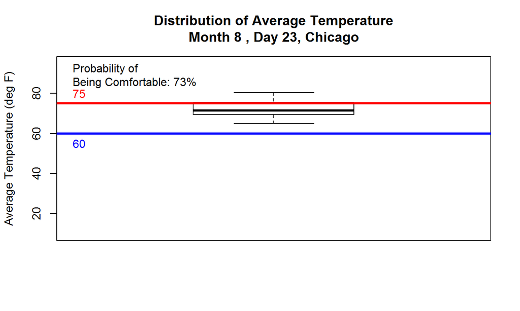